# Discussion 3

Dmitriy Izyumin

January 23, 2017

### Data

We will start with simulated data from an MA(2) process. The function `arima.sim()` used to generate the data will be explained later.

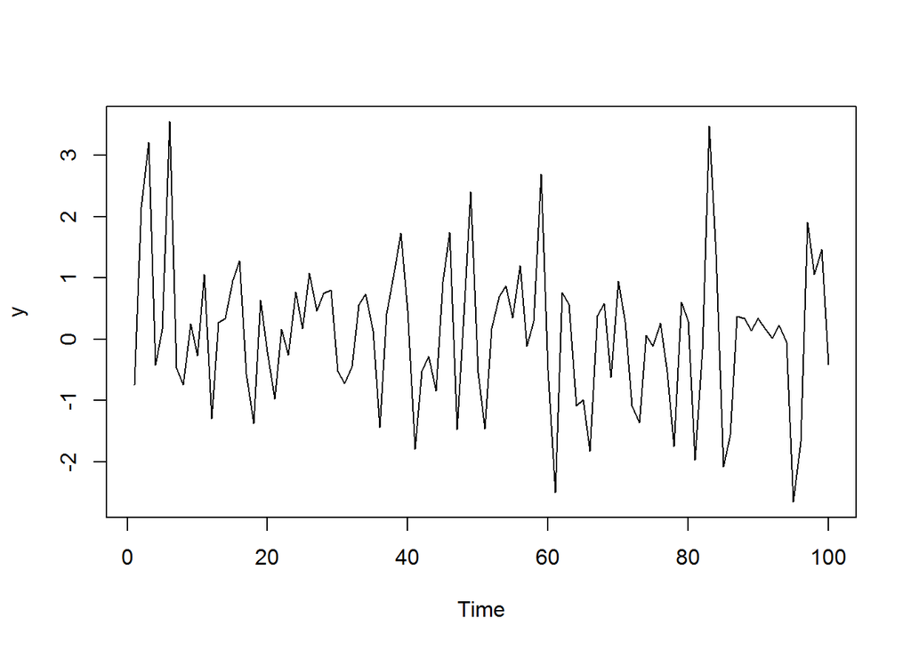

```r
y = arima.sim(100,model=list(ma=c(0.5,-0.6)))
plot.ts(y)
```

### Sample ACF Values

Given a vector of observations, the sample ACF values are computed by the function `acf()`.

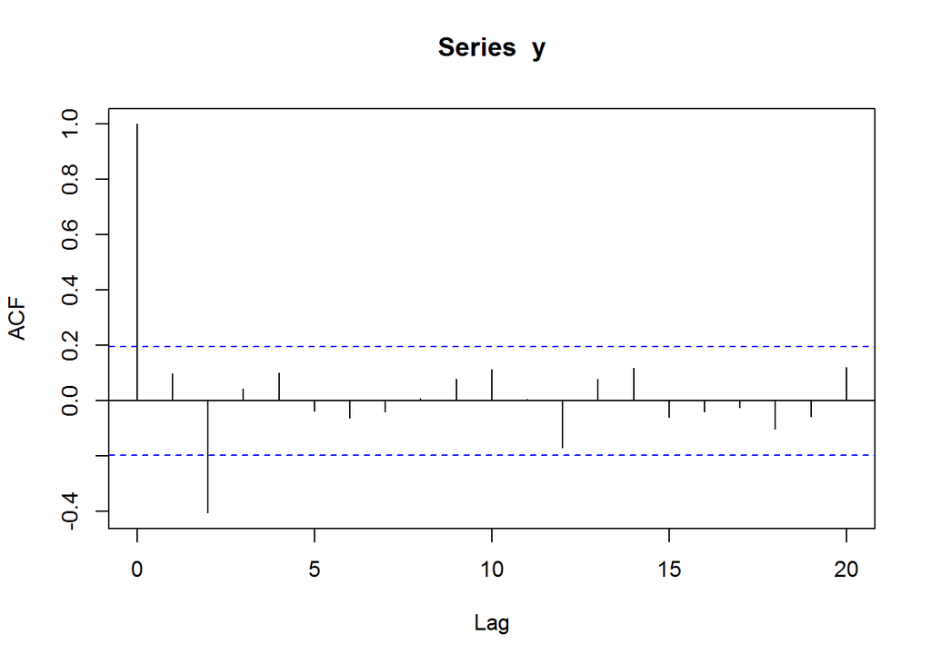

```r
acf(y)
```

By default, a call to `acf()` produces a plot of the sample ACF values for a rather large number of lags, and horizontal bars at $\pm 1.96/\sqrt{n}$. The maximum lag can be specified with the `lag.max` argument. The plot can be further modified by adding standard `plot()` arguments (i.e. `main` for the main title, or `xlab` and `ylab` for axis labels).

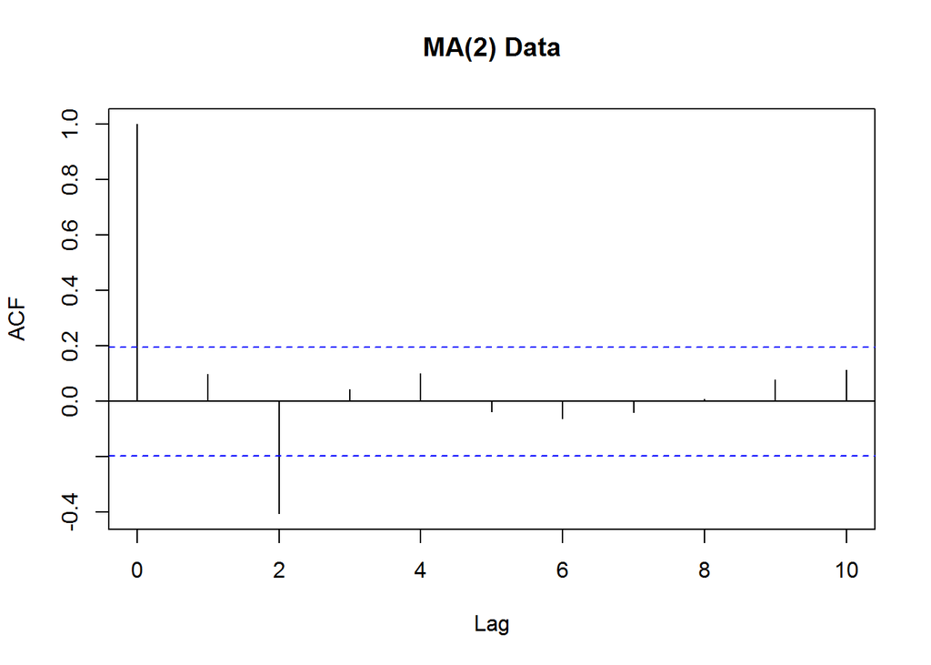

```r
acf(y,lag.max=10,main='MA(2) Data')
```

Finally, it may be the case that you only want a vector of the ACF values, and not a plot. This is often the case if you plan to plug the sample ACF values into another function. To omit the plot, simply type `plot=FALSE` or `plot=F` when you call `acf()`.

```r
acf(y,plot=F)
```

```
##
## Autocorrelations of series 'y', by lag
##
##      0      1      2      3      4      5      6      7      8      9
##  1.000  0.099 -0.405  0.043  0.102 -0.036 -0.062 -0.040  0.008  0.077
##     10     11     12     13     14     15     16     17     18     19
##  0.113  0.006 -0.170  0.078  0.119 -0.059 -0.039 -0.024 -0.102 -0.057
##     20
##  0.121
```

Later on we will also care about something called the Partial AutoCorrelation Function (PACF). To compute and plot the sample PACF values, we will use the `pacf()` function, which is analogous to `acf()`.

### Using Sample ACF to Check Independence

By definition, the sample autocorrelation function (ACF) reports the linear dependence present in the data at different time lags. In other words, the value of the sample ACF at lag $h$ is simply a measure of the linear relationship between sample values measured $h$ time points apart.

Suppose the data come from a process with no time dependence. Under this assumption, the sample ACF values at lags $h \geq 1$ behave like $N(0,1/\sqrt{n})$ random variables. Then a $95\%$ confidence interval for any of those sample ACF values is $(-1.96/\sqrt{n},1.96/\sqrt{n})$. It is for this reason that the ACF plot has horizontal lines at these values.

To verify this, simulate some white noise data and check the sample ACF.

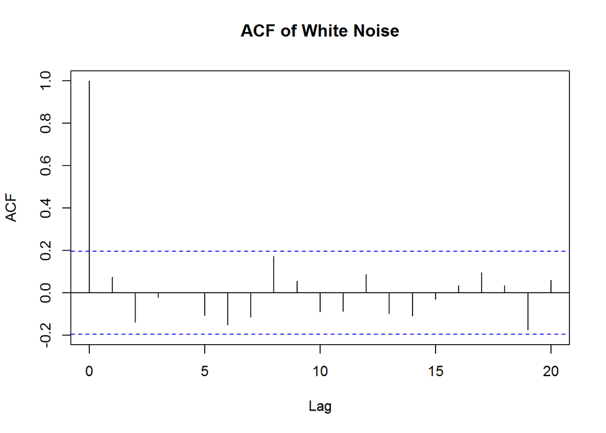

```r
w = rnorm(100,mean=0,sd=10)
acf(w,main='ACF of White Noise')
```

### The Ljung-Box Test

The Ljung-Box test is described in the Diagnostics section of Handout 6. The test uses a statistic based on sample ACF values at lags $1,2,\cdots,h$ to check the null hypothesis of independence. The chosen value of $h$ affects the value of the statistic. In practice, it is recommended to use $h=10$ for non-seasonal data, and $h=2m$ for seasonal data with period $m$. (http://robjhyndman.com/hyndsight/ljung-box-test/)

In R this test is performed by the `Box.test()` command. The value of $h$ is specified by the `lag` argument, and `type='Ljung-Box'` (or simply `type='L'`) specifies the desired test.

```r
Box.test(y,lag=10,type='Ljung-Box')
```

```
##
##  Box-Ljung test
##
## data:  y
## X-squared = 22.235, df = 10, p-value = 0.01395
```

The p-value is very small, and the assumption of independence is rejected for `y`. Let’s see what happens when we apply the test to the simulated white noise data `w`.

```r
Box.test(w,lag=10,type='Ljung-Box')
```

```
##
##  Box-Ljung test
##
## data:  w
## X-squared = 12.336, df = 10, p-value = 0.2632
```

Here the p-value is very large, which means we cannot reject the assumption of independence.

### Not Stationary Data

This data set shows quarterly earnings per share for the U.S. company Johnson & Johnson. There are 84 quarters (21 years) measured from the first quarter of 1960 to the last quarter of 1980. First download the data:

```r
library(astsa)
data("JohnsonJohnson")
jj = JohnsonJohnson
```

Now let’s plot the data and take a look.

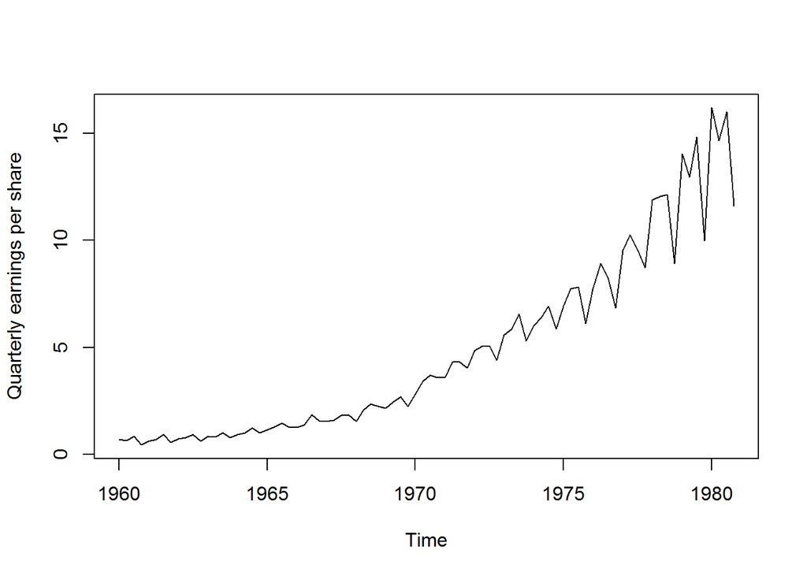

```r
plot(jj, ylab="Quarterly earnings per share")
```

The raw data does not appear to have come from a stationary process. It would not make sense to fit a stationary model here because

- the mean is not constant,
- the variance is not constant,
- there is a seasonal component (data is QUARTERLY, and plot shows seasonality).

The first thing to do is to consider transformations to stabilize the variance. The natural logarithm seems to be appropriate here. Try other transformations to see if you can find one that leads to more constant variance.

```r
logjj = log(jj)
plot(logjj, ylab="Quarterly earnings per share")
```

[output not shown]

From now on, we’re working with the transformed data. Let’s ignore the seasonal component for now, and consider different methods for estimating the trend. Based on the plot, the trend is clearly positive, and likely linear.

### Regression

Let’s first consider modelling the trend using linear regression. It seems that the trend is linear. However, let’s consider a quadratic and a higher order polynomial regression for the sake of example. For the log-transformed JJ data, we will fit the following linear models:

1. $y = \beta_0 + \beta_1x + \epsilon$ : simple linear regression
2. $y = \beta_0 + \beta_1x + \beta_2x^2 +\epsilon$ : quadratic regression
3. $y = \sum_{j=0}^{25}\beta_jx^j + \epsilon$ : Polynomial regression of order 25

where $y$ is called the “response”, while $x$ is the predictor and the $\epsilon$ is the errors where certain assumptions are imposed on it (recall your 108 and 106 classes).

```r
n = length(logjj)
time = 1:n
fit1 = lm(logjj ~ time ) #1
fit2 = lm(logjj ~ poly(time, 2)) #2
fit3 = lm(logjj ~ poly(time, 25)) #3
```

and we can have a look at these three fits against the true values, i.e.,

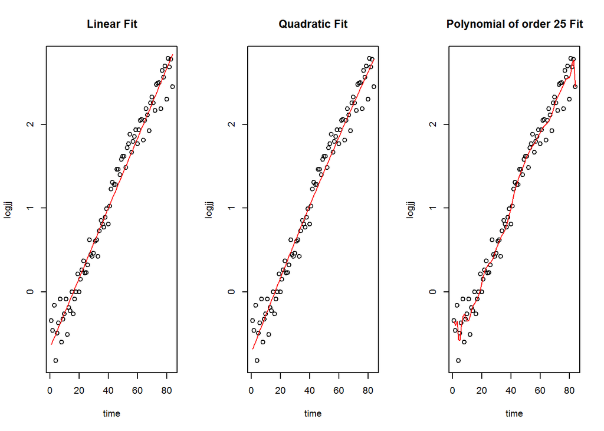

```r
par(mfrow=c(1,3))
plot(time, logjj, main = "Linear Fit")
lines(time, fitted(fit1), col="red")
plot(time, logjj, main = "Quadratic Fit")
lines(time, fitted(fit2), col="red")
plot(time, logjj, main = "Polynomial of order 25 Fit")
lines(time, fitted(fit3), col="red")
```

or one can plot the fitted values on the same plot (note that here we are only plotting the fitted values not the raw data to get a clearer comparisons of the fits)

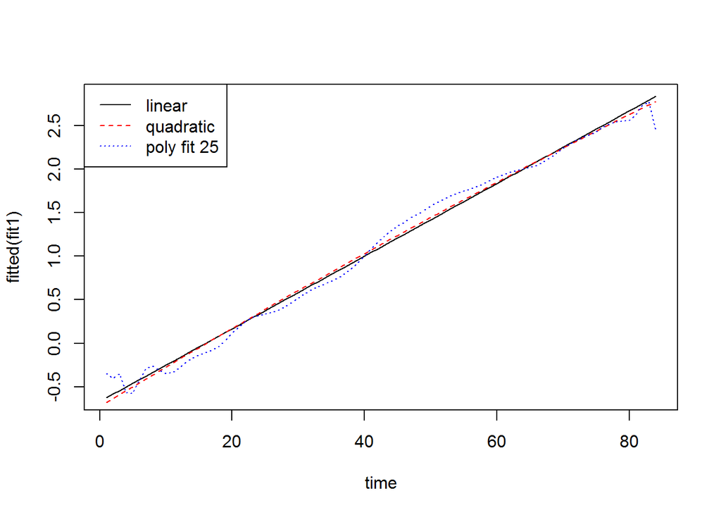

```r
plot(time, fitted(fit1), type="l", col="black", lty=1)
lines(time, fitted(fit2), col="red", lty=2)
lines(time, fitted(fit3), col="blue", lty=3)
legend("topleft",c("linear", "quadratic", "poly fit 25"), col=c("black", "red", "blue"), lty=1:3)
```

Here the quadratic fit tries to mimic the linear regression since the quadratic term $\beta_2$ is almost 0, therefore the shape of quadratic regression line is almost linear. One can actually test the hypothesis of each regression parameter being significant or not, i.e.,
$$H_0:\beta_k=0\quad vs \quad H_A:\beta_k\neq0\qquad k\in\mathbb{N}$$
For example looking at the `summary()` function of the fits, we can see the p-values of each tests, i.e.

```r
summary(fit2) #look at the coefficints component
```

```
##
## Call:
## lm(formula = logjj ~ poly(time, 2))
##
## Residuals:
##      Min       1Q   Median       3Q      Max
## -0.32687 -0.08914  0.00833  0.11021  0.42835
##
## Coefficients:
##                Estimate Std. Error t value Pr(>|t|)
## (Intercept)     1.10444    0.01716  64.354   <2e-16 ***
## poly(time, 2)1  9.26670    0.15729  58.914   <2e-16 ***
## poly(time, 2)2 -0.23882    0.15729  -1.518    0.133
## ---
## Signif. codes:  0 '***' 0.001 '**' 0.01 '*' 0.05 '.' 0.1 ' ' 1
##
## Residual standard error: 0.1573 on 81 degrees of freedom
## Multiple R-squared:  0.9772, Adjusted R-squared:  0.9766
## F-statistic:  1737 on 2 and 81 DF,  p-value: < 2.2e-16
```

As you can see from the p-value for the quadratic coefficient $\beta_2$ which is higher than the level of the test 0.05, hence this coefficient is not significantly different than zero.

We will choose the linear fit here.

```r
trend.reg = fit1$fitted
```

### LOESS

Another method for estimating the trend is local weighted regression, or LOESS. In R it can be conducted using the function `loess()`. Here, you need to specify the `span`. This should be a value between 0 and 1 representing the proportion of the data to use for computing each fitted value. The larger the span, the smoother the fit. Try different values and see for yourself.

```r
alpha = 0.2
mod.loess = loess(logjj~time,span=alpha)
trend.loess = mod.loess$fitted
plot(logjj, ylab="Quarterly earnings per share")
points(time, trend.loess, type = 'l', col = 'red')
```

[output not shown]

### Moving Average

Yet another way to estimate the trend is the moving average. Here, the value of the trend at each time point is estimated by an average of $m$ observations around that time point. We choose $m$ to be odd so that the average is performed using $(m-1)/2$ observations to the left, and $(m-1)/2$ to the right of the chosen time point. As before, the larger the value of $m$, the smoother the fit.

In R this can be done using the `filter()` function as follows.

```r
m = 5
trend.ma = filter(logjj,rep(1/m,m), sides=2)
plot(logjj, ylab="Quarterly earnings per share")
points(time, trend.ma, type = 'l', col = 'red')
```

[output not shown]

### Decompose

We noted earlier that the data has a seasonal component (of period 4) as well. Since the data exhibits both a trend, and a seasonal component, we can use the function `decompose()` to obtain a classical decomposition of the data into the trend, seasonal, and random components.

```r
mod.dec = decompose(logjj)
names(mod.dec)
```

```
## [1] "x"        "seasonal" "trend"    "random"   "figure"   "type"
```

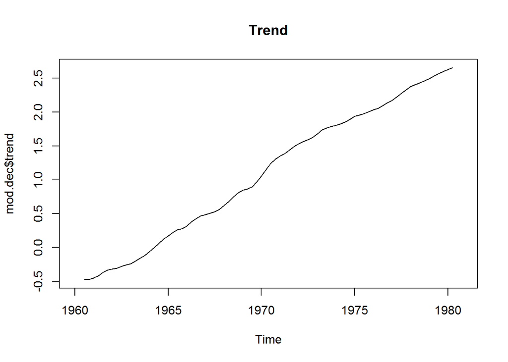

```r
plot(mod.dec$trend, main = 'Trend')
```

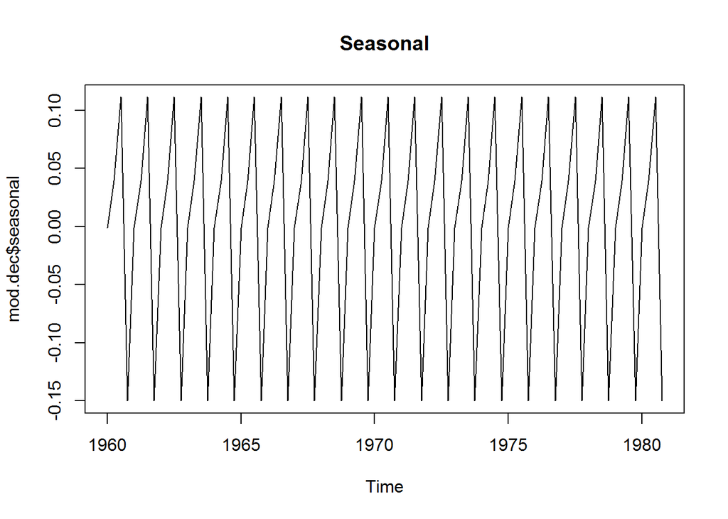

```r
plot(mod.dec$seasonal, main = 'Seasonal')
```

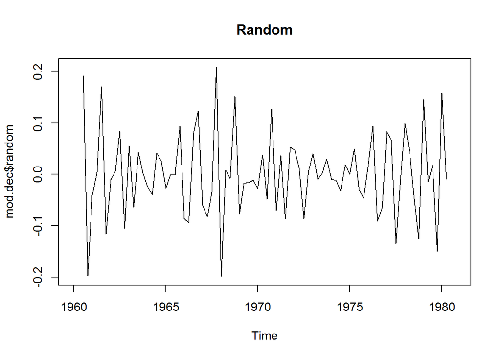

```r
plot(mod.dec$random, main = 'Random')
```

Pay attention to the component called “Random.” This is the data with the trend and seasonal components removed, and hopefully it should look stationary. If it looks stationary, we can consider fitting a stationary model to it.

Notice that here the random component still doesn’t look ideal, as there is still some unequal variance. Moreover, it seems the values are not from an i.i.d. process, as there appears to be some periodic structure even after the seasonal component has been removed.

Let’s return to the ACF diagnostics, and check if this data has a covariance structure.

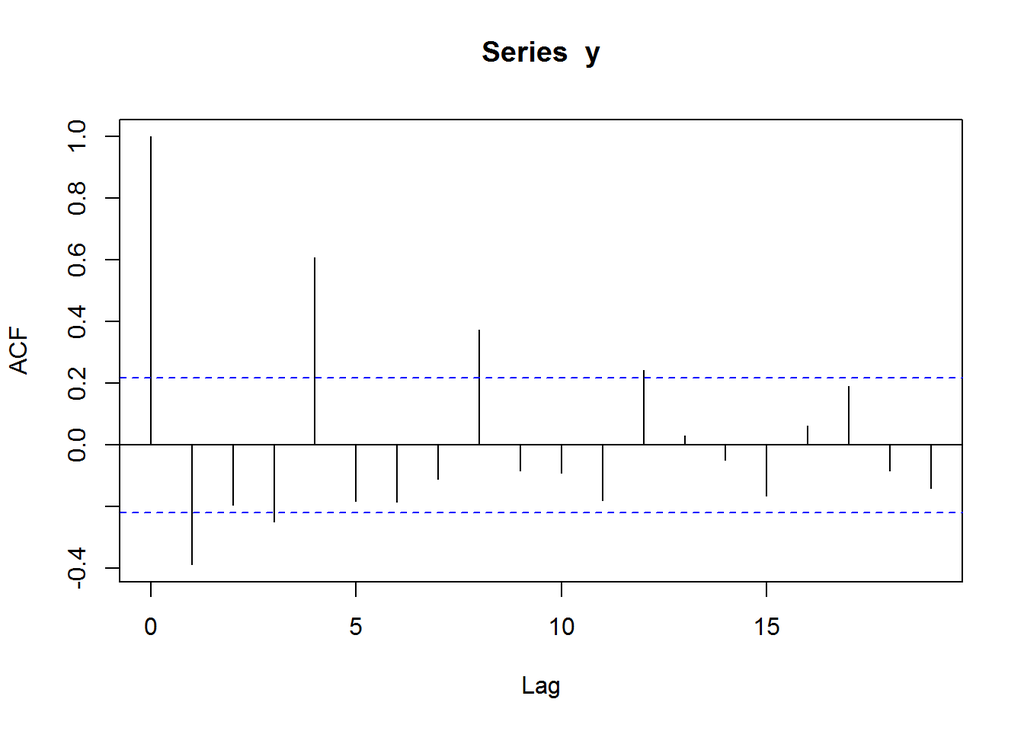

```r
y = mod.dec$random
y = y[!is.na(y)]
acf(y)
```

```r
Box.test(y, lag = 10, type = 'Ljung')
```

```
##
##  Box-Ljung test
##
## data:  y
## X-squared = 74.11, df = 10, p-value = 7.088e-12
```

Both the ACF and the Box-Ljung test indicate that the data does have a dependence structure.